# STAT0032 ICA 1

Ian

2022-11-21

## Task 1: A Study of the distribution of bike hires during peak commute times in the evening

- We are focused on Spring and Summer
  - will filter accordingly, based on TfL’s official evening hours: between 16:00 and 19:00 on Weekdays (source: tfl.gov.uk)
  - naturally, we will filter for working days as this gives meaning to the peak commute times focus
  - from instant, dteday, season, yr, mnth, hr, holiday, weekday, workingday, weathersit, temp, atemp, hum, windspeed, casual, registered, cnt, we will only use season, cnt, workingday for the subsetting

```r
## Both seasons, working days, evenings
peak_commute_evening <- data %>% filter(season == 2 | season == 3) %>% filter(workingday == 1) %>% filter(is.element(hr,(16:19)))

pce_summer <- peak_commute_evening %>% filter(season == 3)
pce_spring <- peak_commute_evening %>% filter(season == 2)
```

## Basic visualisation

Before diving into the quantitative tests, it would be good to have a look at the univariate plots to examine the distribution:

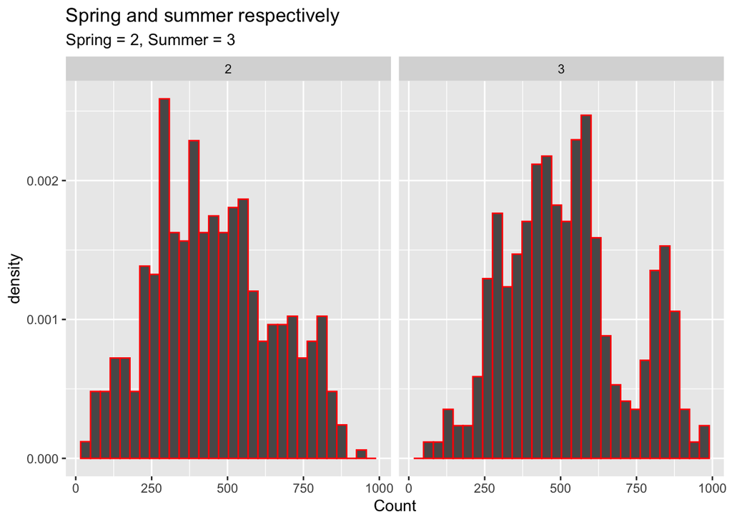

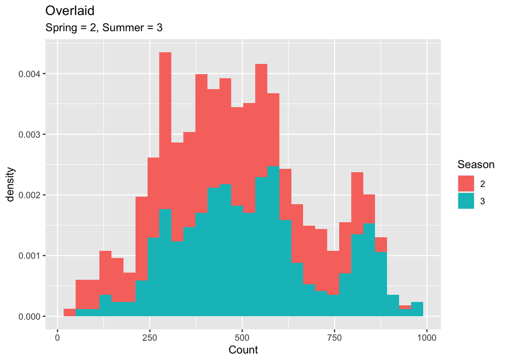

Analysis

- we can see that summer distribution looks more like a bimodal normal rather than a ‘normal’ normal distribution with a single mode
- this will give us more insight when we run the quantitative tests below

## Testing

### 1. Lillefors Test

- Adapted from Kolmogorov Smirnov test of goodness of fit for normality, but when the mean and variance are estimated from the data instead of given
- Methodolodgy : finds the difference between the empirical CDF and the theoretical CDF of the normal distribution using the estimated mean and variance from the data, and assesses the maximum discrepancy (source: https://en.wikipedia.org/wiki/Lilliefors_test)

```r
library(nortest)
l1<- lillie.test(pce_spring$cnt)
l2 <- lillie.test(pce_summer$cnt)
l1; l2
```

```
##
##  Lilliefors (Kolmogorov-Smirnov) normality test
##
## data:  pce_spring$cnt
## D = 0.04529, p-value = 0.01396
```

```
##
##  Lilliefors (Kolmogorov-Smirnov) normality test
##
## data:  pce_summer$cnt
## D = 0.072897, p-value = 5.364e-07
```

### 2. Shapiro Wilk Test

```r
s1 <- shapiro.test(pce_spring$cnt)
s2 <- shapiro.test(pce_summer$cnt)
s1; s2
```

```
##
##  Shapiro-Wilk normality test
##
## data:  pce_spring$cnt
## W = 0.98408, p-value = 2.156e-05
```

```
##
##  Shapiro-Wilk normality test
##
## data:  pce_summer$cnt
## W = 0.97452, p-value = 6.563e-08
```

### 3. Anderson-Darling

```r
a1 <- ad.test(pce_spring$cnt)
a2 <- ad.test(pce_spring$cnt)
a1; a2
```

```
##
##  Anderson-Darling normality test
##
## data:  pce_spring$cnt
## A = 1.9635, p-value = 5.219e-05
```

```
##
##  Anderson-Darling normality test
##
## data:  pce_spring$cnt
## A = 1.9635, p-value = 5.219e-05
```

```r
pvaluetable <- data.frame(row.names = c("Spring", "Summer"),
          Lillefors = c(l1$p.value, l2$p.value),
          Shapiro = c(s1$p.value,s2$p.value),
          AD = c(a1$p.value, a2$p.value))
pvaluetable
```

[output not shown]

### Power Analysis

Power analysis Monte Carlo simulation has found that Shapiro–Wilk has the best power for a given significance, followed closely by Anderson–Darling when comparing the Shapiro–Wilk, Kolmogorov–Smirnov, and Lilliefors.(Source: Wikipedia)

### Bonferroni correction

Due to multiple testing, we end up with a higher chance of committing a type 1 error (rejecting when H0 is true) if we use the same significance level, hence we divide up the alpha by 3 for each of the test.

However, due to the small p values from all our test (largest is for Lillefors 0.014 < 0.016), this is not an issue, and we still reject all null hypothesises.